# Ford Go Bike System Data

```python
# Checking if the start station id and end station id is same
bike_share[bike_share['end_station_id']==bike_share['start_station_id']]
# We can see that there are almost 51975 instances where the user started and ended at the same place
```

|  | bike_id | bike_share_for_all_trip | duration_sec | end_station_id | end_station_name | member_birth_year | member_gender | start_station_id | start_station_name | user_type | start_date_dt | start_time_dt | end_date_dt | end_time_dt |
| --- | --- | --- | --- | --- | --- | --- | --- | --- | --- | --- | --- | --- | --- | --- |
| 6 | 3539 | NaN | 4507 | 259.0 | Addison St at Fourth St | 1991.0 | Female | 259.0 | Addison St at Fourth St | Customer | 2017-12-31 | 23:49:28 | 2018-01-01 | 01:04:35 |
| 64 | 2732 | NaN | 547 | 30.0 | San Francisco Caltrain (Townsend St at 4th St) | 1994.0 | Female | 30.0 | San Francisco Caltrain (Townsend St at 4th St) | Subscriber | 2017-12-31 | 22:52:35 | 2017-12-31 | 23:01:43 |
| 76 | 1533 | NaN | 2646 | 7.0 | Frank H Ogawa Plaza | 1980.0 | Male | 7.0 | Frank H Ogawa Plaza | Subscriber | 2017-12-31 | 22:02:13 | 2017-12-31 | 22:46:19 |
| 86 | 3022 | NaN | 1961 | 41.0 | Golden Gate Ave at Polk St | 1958.0 | Male | 41.0 | Golden Gate Ave at Polk St | Subscriber | 2017-12-31 | 21:59:37 | 2017-12-31 | 22:32:18 |
| 187 | 2633 | NaN | 1609 | 70.0 | Central Ave at Fell St | 1981.0 | Male | 70.0 | Central Ave at Fell St | Subscriber | 2017-12-31 | 19:50:52 | 2017-12-31 | 20:17:41 |
| 219 | 2800 | NaN | 165 | 13.0 | Commercial St at Montgomery St | 1994.0 | Male | 13.0 | Commercial St at Montgomery St | Subscriber | 2017-12-31 | 19:50:30 | 2017-12-31 | 19:53:16 |
| 310 | 2456 | NaN | 1596 | 6.0 | The Embarcadero at Sansome St | 1994.0 | Male | 6.0 | The Embarcadero at Sansome St | Customer | 2017-12-31 | 17:35:13 | 2017-12-31 | 18:01:49 |
| 326 | 2119 | NaN | 223 | 125.0 | 20th St at Bryant St | 1992.0 | Male | 125.0 | 20th St at Bryant St | Subscriber | 2017-12-31 | 17:45:56 | 2017-12-31 | 17:49:40 |
| 349 | 746 | NaN | 10509 | 72.0 | Page St at Scott St | 1979.0 | Male | 72.0 | Page St at Scott St | Subscriber | 2017-12-31 | 14:38:46 | 2017-12-31 | 17:33:56 |
| 357 | 3713 | NaN | 2158 | 74.0 | Laguna St at Hayes St | 1994.0 | Female | 74.0 | Laguna St at Hayes St | Customer | 2017-12-31 | 16:55:21 | 2017-12-31 | 17:31:19 |
| 371 | 1821 | NaN | 4857 | 126.0 | Esprit Park | 1994.0 | Female | 126.0 | Esprit Park | Customer | 2017-12-31 | 16:02:27 | 2017-12-31 | 17:23:24 |
| 442 | 2831 | NaN | 2391 | 6.0 | The Embarcadero at Sansome St | 1988.0 | Male | 6.0 | The Embarcadero at Sansome St | Subscriber | 2017-12-31 | 16:04:11 | 2017-12-31 | 16:44:03 |
| 467 | 1984 | NaN | 972 | 285.0 | Webster St at O'Farrell St | 1979.0 | Male | 285.0 | Webster St at O'Farrell St | Subscriber | 2017-12-31 | 16:17:05 | 2017-12-31 | 16:33:18 |
| 469 | 2926 | NaN | 868 | 285.0 | Webster St at O'Farrell St | 1986.0 | Female | 285.0 | Webster St at O'Farrell St | Subscriber | 2017-12-31 | 16:18:10 | 2017-12-31 | 16:32:38 |
| 490 | 3224 | NaN | 2191 | 120.0 | Mission Dolores Park | 1988.0 | Male | 120.0 | Mission Dolores Park | Customer | 2017-12-31 | 15:47:41 | 2017-12-31 | 16:24:13 |
| 492 | 661 | NaN | 2179 | 120.0 | Mission Dolores Park | 1992.0 | Male | 120.0 | Mission Dolores Park | Customer | 2017-12-31 | 15:47:42 | 2017-12-31 | 16:24:01 |
| 494 | 1100 | NaN | 2613 | 70.0 | Central Ave at Fell St | 1984.0 | Female | 70.0 | Central Ave at Fell St | Customer | 2017-12-31 | 15:36:15 | 2017-12-31 | 16:19:49 |
| 495 | 1689 | NaN | 2615 | 70.0 | Central Ave at Fell St | 1984.0 | Male | 70.0 | Central Ave at Fell St | Customer | 2017-12-31 | 15:36:12 | 2017-12-31 | 16:19:47 |
| 517 | 1449 | NaN | 81 | 237.0 | Fruitvale BART Station | 1990.0 | Female | 237.0 | Fruitvale BART Station | Subscriber | 2017-12-31 | 16:09:26 | 2017-12-31 | 16:10:48 |
| 525 | 3010 | NaN | 296 | 81.0 | Berry St at 4th St | 1993.0 | Male | 81.0 | Berry St at 4th St | Subscriber | 2017-12-31 | 15:58:47 | 2017-12-31 | 16:03:44 |
| 546 | 2927 | NaN | 1219 | 148.0 | Horton St at 40th St | 1964.0 | Female | 148.0 | Horton St at 40th St | Subscriber | 2017-12-31 | 15:38:23 | 2017-12-31 | 15:58:42 |
| 558 | 2311 | NaN | 5012 | 70.0 | Central Ave at Fell St | 1990.0 | Male | 70.0 | Central Ave at Fell St | Customer | 2017-12-31 | 14:27:47 | 2017-12-31 | 15:51:19 |
| 559 | 139 | NaN | 4649 | 70.0 | Central Ave at Fell St | 1991.0 | Female | 70.0 | Central Ave at Fell St | Customer | 2017-12-31 | 14:33:44 | 2017-12-31 | 15:51:13 |
| 585 | 117 | NaN | 131 | 176.0 | MacArthur BART Station | 1961.0 | Female | 176.0 | MacArthur BART Station | Subscriber | 2017-12-31 | 15:40:30 | 2017-12-31 | 15:42:41 |
| 660 | 2254 | NaN | 7439 | 263.0 | Channing Way at San Pablo Ave | 1983.0 | Female | 263.0 | Channing Way at San Pablo Ave | Customer | 2017-12-31 | 13:05:24 | 2017-12-31 | 15:09:23 |
| 662 | 2831 | NaN | 235 | 60.0 | 8th St at Ringold St | 1988.0 | Male | 60.0 | 8th St at Ringold St | Subscriber | 2017-12-31 | 15:03:48 | 2017-12-31 | 15:07:44 |
| 697 | 2256 | NaN | 256 | 43.0 | San Francisco Public Library (Grove St at Hyde... | 1978.0 | Female | 43.0 | San Francisco Public Library (Grove St at Hyde... | Customer | 2017-12-31 | 14:49:19 | 2017-12-31 | 14:53:36 |
| 782 | 1759 | NaN | 1307 | 28.0 | The Embarcadero at Bryant St | 1991.0 | Female | 28.0 | The Embarcadero at Bryant St | Customer | 2017-12-31 | 13:59:12 | 2017-12-31 | 14:20:59 |
| 784 | 3254 | NaN | 1199 | 28.0 | The Embarcadero at Bryant St | 1993.0 | Male | 28.0 | The Embarcadero at Bryant St | Subscriber | 2017-12-31 | 13:59:05 | 2017-12-31 | 14:19:04 |
| 827 | 1961 | NaN | 768 | 279.0 | Santa Clara St at 7th St | 1993.0 | Male | 279.0 | Santa Clara St at 7th St | Subscriber | 2017-12-31 | 13:53:51 | 2017-12-31 | 14:06:39 |
| ... | ... | ... | ... | ... | ... | ... | ... | ... | ... | ... | ... | ... | ... | ... |
| 2382065 | 2187 | No | 1015 | 123.0 | Folsom St at 19th St | 1986.0 | Male | 123.0 | Folsom St at 19th St | Subscriber | 2018-12-01 | 15:31:30 | 2018-12-01 | 15:48:26 |
| 2382145 | 3327 | No | 1203 | 197.0 | El Embarcadero at Grand Ave | 1996.0 | Male | 197.0 | El Embarcadero at Grand Ave | Subscriber | 2018-12-01 | 15:07:55 | 2018-12-01 | 15:27:59 |
| 2382152 | 1614 | Yes | 149 | 296.0 | 5th St at Virginia St | 1995.0 | Female | 296.0 | 5th St at Virginia St | Subscriber | 2018-12-01 | 15:24:47 | 2018-12-01 | 15:27:16 |
| 2382282 | 3522 | Yes | 1480 | 160.0 | West Oakland BART Station | 1959.0 | Male | 160.0 | West Oakland BART Station | Subscriber | 2018-12-01 | 14:28:38 | 2018-12-01 | 14:53:18 |
| 2382337 | 59 | No | 1102 | 129.0 | Harrison St at 20th St | 1958.0 | Male | 129.0 | Harrison St at 20th St | Subscriber | 2018-12-01 | 14:15:55 | 2018-12-01 | 14:34:18 |
| 2382415 | 2434 | No | 5991 | 31.0 | Raymond Kimbell Playground | 1986.0 | Male | 31.0 | Raymond Kimbell Playground | Customer | 2018-12-01 | 12:37:50 | 2018-12-01 | 14:17:42 |
| 2382442 | 3256 | Yes | 1253 | 237.0 | Fruitvale BART Station | 1968.0 | Female | 237.0 | Fruitvale BART Station | Subscriber | 2018-12-01 | 13:47:01 | 2018-12-01 | 14:07:54 |
| 2382466 | 449 | No | 5436 | 52.0 | McAllister St at Baker St | 1988.0 | Female | 52.0 | McAllister St at Baker St | Subscriber | 2018-12-01 | 12:28:54 | 2018-12-01 | 13:59:30 |
| 2382515 | 2509 | Yes | 1396 | 277.0 | Morrison Ave at Julian St | 1993.0 | Male | 277.0 | Morrison Ave at Julian St | Subscriber | 2018-12-01 | 13:21:23 | 2018-12-01 | 13:44:39 |
| 2382516 | 245 | Yes | 1346 | 277.0 | Morrison Ave at Julian St | 1995.0 | Male | 277.0 | Morrison Ave at Julian St | Subscriber | 2018-12-01 | 13:21:47 | 2018-12-01 | 13:44:13 |
| 2382535 | 1958 | No | 2605 | 272.0 | Woolsey St at Sacramento St1 | 1993.0 | Male | 272.0 | Woolsey St at Sacramento St1 | Customer | 2018-12-01 | 12:53:36 | 2018-12-01 | 13:37:02 |
| 2382631 | 2119 | No | 189 | 11.0 | Davis St at Jackson St | 1984.0 | Male | 11.0 | Davis St at Jackson St | Subscriber | 2018-12-01 | 13:06:50 | 2018-12-01 | 13:09:59 |
| 2382649 | 3405 | No | 64 | 50.0 | 2nd St at Townsend St | 1977.0 | Female | 50.0 | 2nd St at Townsend St | Subscriber | 2018-12-01 | 13:02:28 | 2018-12-01 | 13:03:33 |
| 2382687 | 3488 | No | 776 | 255.0 | Virginia St at Shattuck Ave | 1959.0 | Male | 255.0 | Virginia St at Shattuck Ave | Customer | 2018-12-01 | 12:41:36 | 2018-12-01 | 12:54:32 |
| 2382726 | 3518 | No | 969 | 351.0 | 10th St at University Ave | 1995.0 | Male | 351.0 | 10th St at University Ave | Customer | 2018-12-01 | 12:26:06 | 2018-12-01 | 12:42:15 |
| 2382769 | 2747 | No | 1548 | 259.0 | Addison St at Fourth St | 1961.0 | Male | 259.0 | Addison St at Fourth St | Customer | 2018-12-01 | 12:00:12 | 2018-12-01 | 12:26:00 |
| 2382780 | 755 | No | 1302 | 163.0 | Lake Merritt BART Station | 1988.0 | Male | 163.0 | Lake Merritt BART Station | Customer | 2018-12-01 | 12:01:56 | 2018-12-01 | 12:23:39 |
| 2382826 | 710 | No | 594 | 7.0 | Frank H Ogawa Plaza | 1977.0 | Male | 7.0 | Frank H Ogawa Plaza | Subscriber | 2018-12-01 | 11:58:57 | 2018-12-01 | 12:08:52 |
| 2382865 | 1043 | No | 760 | 61.0 | Howard St at 8th St | 1957.0 | Male | 61.0 | Howard St at 8th St | Subscriber | 2018-12-01 | 11:44:39 | 2018-12-01 | 11:57:19 |
| 2382889 | 624 | No | 560 | 55.0 | Webster St at Grove St | 1964.0 | Male | 55.0 | Webster St at Grove St | Subscriber | 2018-12-01 | 11:42:56 | 2018-12-01 | 11:52:16 |
| 2382921 | 3089 | No | 1472 | 239.0 | Bancroft Way at Telegraph Ave | 1996.0 | Male | 239.0 | Bancroft Way at Telegraph Ave | Customer | 2018-12-01 | 11:14:52 | 2018-12-01 | 11:39:25 |
| 2382941 | 3382 | No | 1689 | 252.0 | Channing Way at Shattuck Ave | 1989.0 | Male | 252.0 | Channing Way at Shattuck Ave | Customer | 2018-12-01 | 11:03:03 | 2018-12-01 | 11:31:13 |
| 2382954 | 1533 | No | 1115 | 196.0 | Grand Ave at Perkins St | 1970.0 | Female | 196.0 | Grand Ave at Perkins St | Subscriber | 2018-12-01 | 11:05:31 | 2018-12-01 | 11:24:06 |
| 2382997 | 2914 | No | 944 | 17.0 | Embarcadero BART Station (Beale St at Market St) | 1995.0 | Male | 17.0 | Embarcadero BART Station (Beale St at Market St) | Subscriber | 2018-12-01 | 10:51:50 | 2018-12-01 | 11:07:34 |
| 2383014 | 1686 | No | 91 | 321.0 | 5th St at Folsom | 1989.0 | Male | 321.0 | 5th St at Folsom | Customer | 2018-12-01 | 10:59:55 | 2018-12-01 | 11:01:27 |
| 2383142 | 4320 | Yes | 73 | 22.0 | Howard St at Beale St | 1979.0 | Male | 22.0 | Howard St at Beale St | Subscriber | 2018-12-01 | 09:26:14 | 2018-12-01 | 09:27:27 |
| 2383145 | 3574 | No | 1502 | 74.0 | Laguna St at Hayes St | 1983.0 | Female | 74.0 | Laguna St at Hayes St | Subscriber | 2018-12-01 | 09:00:00 | 2018-12-01 | 09:25:03 |
| 2383166 | 3742 | No | 1130 | 92.0 | Mission Bay Kids Park | 1984.0 | Female | 92.0 | Mission Bay Kids Park | Customer | 2018-12-01 | 08:52:01 | 2018-12-01 | 09:10:52 |
| 2383209 | 3035 | No | 2114 | 81.0 | Berry St at 4th St | 1968.0 | Female | 81.0 | Berry St at 4th St | Customer | 2018-12-01 | 08:12:43 | 2018-12-01 | 08:47:57 |
| 2383267 | 184 | No | 822 | 109.0 | 17th St at Valencia St | 1986.0 | Male | 109.0 | 17th St at Valencia St | Subscriber | 2018-12-01 | 07:29:58 | 2018-12-01 | 07:43:40 |

51975 rows × 14 columns

## Univariate Exploration

```python
sns.set_style('whitegrid') # setting plot background
```

# Lets explore each variable distribution during the univariate exploration phase

Let see how rides are distributed in 2018 vs 2017

```python
# Rides by year
```

```python
bike_share['end_date_dt']=pd.to_datetime(bike_share['end_date_dt'])
bike_share['start_date_dt']=pd.to_datetime(bike_share['start_date_dt'])
```

```python
bike_share['end_year']=bike_share['end_date_dt'].dt.year
bike_share['start_year']=bike_share['start_date_dt'].dt.year
```

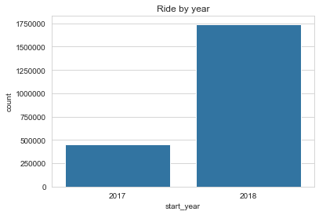

```python
base_color=sns.color_palette()[0]
sns.countplot(data=bike_share,x='start_year',color=base_color)
plt.title('Ride by year')
```

```python
# Breaking down rides month wise in 2018 and 2019

bike_share_2018=bike_share[bike_share['start_year']==2018]
bike_share_2017=bike_share[bike_share['start_year']==2017]
```

```python
bike_share_2017['start_month']= bike_share_2017['start_date_dt'].dt.month
bike_share_2018['start_month']=bike_share_2018['start_date_dt'].dt.month
bike_share_2018['end_month']=bike_share_2018['end_date_dt'].dt.month
```

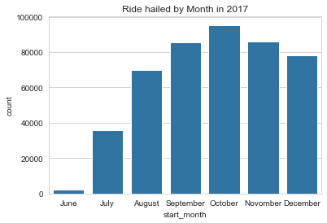

```python
sns.countplot(data=bike_share_2017,x='start_month',color=base_color);
loc=[0,1,2,3,4,5,6]
labels=["June",'July','August','September','October','Novomber','December']
plt.xticks(loc,labels);
plt.title('Ride hailed by Month in 2017') ;
```

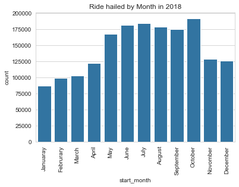

```python
sns.countplot(data=bike_share_2018,x='start_month',color=base_color);
loc=[0,1,2,3,4,5,6,7,8,9,10,11]
labels=['Januaray','Februrary','March','April','May',"June",'July','August','September','October','Novomber','December']
plt.xticks(loc,labels,rotation=90);
plt.title('Ride hailed by Month in 2018');
```

The reason for less rides in 2017 could be that the date recording started late or the company started operations in june of 2017

As the data is less in 2017 Let analyse trends in 2018 only . Also we can right now see that rides hailed between June- Dec 2018 are much higher than the same time frame in 2017 . Hence we can safely conclude that whatever promotion tactics the company used to get people worked

Let see how the time duration is distributed

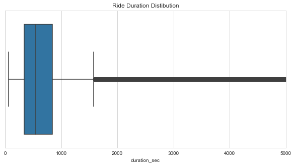

```python
plt.figure(figsize=(10,5))
sns.boxplot(bike_share_2018['duration_sec'])
plt.xlim((0,5000));
plt.title('Ride Duration Distibution');
```

This box plot shows us that median of the data lies some where close too 550 seconds. Let plot a histogram to see how the duration time in sec is distributed

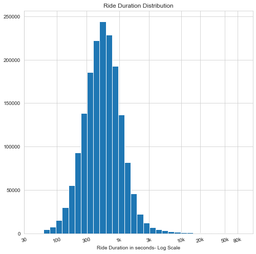

```python
bin_range=10**np.arange(np.log10(bike_share_2018['duration_sec'].min()),np.log10(bike_share_2018['duration_sec'].max())+0.1,0.1)
plt.figure(figsize=(8,8))
plt.hist(x=bike_share_2018['duration_sec'],bins=bin_range);
plt.xscale('log')
labels=[30,100,300,1000,3000,10000,20000,50000,80000]
marks=[30,100,300,'1k','3k','10k','20k','50k','80k']
plt.xticks(labels,marks,rotation=15);
plt.xlabel('Ride Duration in seconds- Log Scale');
plt.title('Ride Duration Distribution');
```

We see how our variable of interest is distributed in the graph above. The graph is made by using the log scale on X axis  
We see almost all the rides lasting less than 10,000 secs with majority of rides less than 3000 secs

Now let see how the gender count is distributed

```python
bike_share.member_gender.unique()
# We see there are gender as displayed below
```

```
array(['Male', 'Female', 'Other'], dtype=object)
```

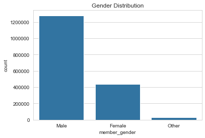

```python
# To see the male vs female distribution
base_color=sns.color_palette()[0]
sns.countplot(data=bike_share_2018,x='member_gender',color=base_color)
plt.title("Gender Distribution");
```

Lets see how many user vs subscribers are there in the dataset

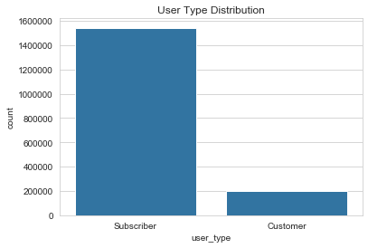

```python
sns.countplot(data=bike_share_2018,x='user_type',color=base_color);
plt.title("User Type Distribution");
```

> I will also be intrested to know the average ride duration for subscriber vs Customer to see who's rides are longer  
> during bivariate distribution phase

Let check the distibution of member birth year

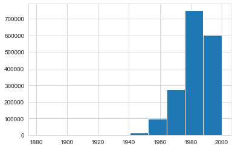

```python
plt.hist(x=bike_share_2018['member_birth_year']);
```

```python
#Checking the min DOB in the dataset
bike_share_2018.member_birth_year.min()
```

```
1881.0
```

We see that there are some years are starting from 1880 and gng upto 2000.

> Lets keep data for 89 years from 2018 so upto 1930

```python
bike_share_2018=bike_share_2018[bike_share_2018['member_birth_year']>=1930]
```

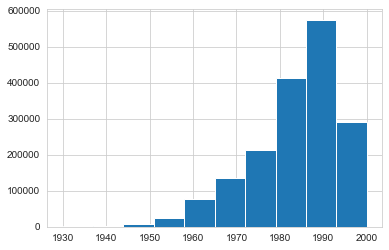

```python
# Replotting again
plt.hist(x=bike_share_2018['member_birth_year']);
```

we see that the most people born in 1980s and 1990s are using the service

```python
# let see if there is any ride which did not end in the same year .

bike_share_2018[bike_share_2018['end_year']!=bike_share_2018['start_year']]
# Looks like we have 12 rides which started close to the new year eve .
```

|  | bike_id | bike_share_for_all_trip | duration_sec | end_station_id | end_station_name | member_birth_year | member_gender | start_station_id | start_station_name | user_type | start_date_dt | start_time_dt | end_date_dt | end_time_dt | end_year | start_year | start_month | end_month |
| --- | --- | --- | --- | --- | --- | --- | --- | --- | --- | --- | --- | --- | --- | --- | --- | --- | --- | --- |
| 2252061 | 5422 | Yes | 30550 | 19.0 | Post St at Kearny St | 1986.0 | Male | 13.0 | Commercial St at Montgomery St | Subscriber | 2018-12-31 | 19:26:20 | 2019-01-01 | 03:55:30 | 2019 | 2018 | 12 | 1 |
| 2252063 | 5549 | Yes | 2149 | 368.0 | Myrtle St at Polk St | 1982.0 | Male | 3.0 | Powell St BART Station (Market St at 4th St) | Subscriber | 2018-12-31 | 23:59:11 | 2019-01-01 | 00:35:01 | 2019 | 2018 | 12 | 1 |
| 2252064 | 4706 | No | 2502 | 44.0 | Civic Center/UN Plaza BART Station (Market St ... | 1973.0 | Male | 67.0 | San Francisco Caltrain Station 2 (Townsend St... | Customer | 2018-12-31 | 23:46:24 | 2019-01-01 | 00:28:07 | 2019 | 2018 | 12 | 1 |
| 2252065 | 5518 | No | 8202 | 16.0 | Steuart St at Market St | 1995.0 | Male | 324.0 | Union Square (Powell St at Post St) | Customer | 2018-12-31 | 22:11:22 | 2019-01-01 | 00:28:05 | 2019 | 2018 | 12 | 1 |
| 2252066 | 4800 | No | 2170 | 21.0 | Montgomery St BART Station (Market St at 2nd St) | 1999.0 | Female | 6.0 | The Embarcadero at Sansome St | Customer | 2018-12-31 | 23:47:19 | 2019-01-01 | 00:23:30 | 2019 | 2018 | 12 | 1 |
| 2252067 | 4747 | No | 3645 | 8.0 | The Embarcadero at Vallejo St | 1999.0 | Male | 6.0 | The Embarcadero at Sansome St | Customer | 2018-12-31 | 23:22:41 | 2019-01-01 | 00:23:27 | 2019 | 2018 | 12 | 1 |
| 2252068 | 5426 | No | 2182 | 21.0 | Montgomery St BART Station (Market St at 2nd St) | 1999.0 | Female | 6.0 | The Embarcadero at Sansome St | Customer | 2018-12-31 | 23:47:02 | 2019-01-01 | 00:23:24 | 2019 | 2018 | 12 | 1 |
| 2252070 | 1047 | Yes | 972 | 238.0 | MLK Jr Way at University Ave | 1985.0 | Male | 238.0 | MLK Jr Way at University Ave | Subscriber | 2018-12-31 | 23:52:27 | 2019-01-01 | 00:08:39 | 2019 | 2018 | 12 | 1 |
| 2252071 | 3502 | No | 683 | 245.0 | Downtown Berkeley BART | 2000.0 | Male | 247.0 | Fulton St at Bancroft Way | Customer | 2018-12-31 | 23:52:33 | 2019-01-01 | 00:03:57 | 2019 | 2018 | 12 | 1 |
| 2252072 | 4615 | No | 868 | 23.0 | The Embarcadero at Steuart St | 1984.0 | Male | 350.0 | 8th St at Brannan St | Subscriber | 2018-12-31 | 23:46:34 | 2019-01-01 | 00:01:02 | 2019 | 2018 | 12 | 1 |
| 2252073 | 4811 | No | 814 | 23.0 | The Embarcadero at Steuart St | 1988.0 | Female | 350.0 | 8th St at Brannan St | Subscriber | 2018-12-31 | 23:47:20 | 2019-01-01 | 00:00:54 | 2019 | 2018 | 12 | 1 |
| 2252074 | 5357 | No | 816 | 23.0 | The Embarcadero at Steuart St | 1982.0 | Male | 350.0 | 8th St at Brannan St | Customer | 2018-12-31 | 23:47:16 | 2019-01-01 | 00:00:53 | 2019 | 2018 | 12 | 1 |